# Coordinates

GeodeticOps provides seven coordinate types organized into a type hierarchy that distinguishes *fixed* coordinates (those that describe a position on the ellipsoid) from *relative* coordinates (those measured from a local reference point).

## Type Hierarchy

```
AbstractCoords{T}
├── AbstractFixedCoords{T}       # convertible to LLA with only a Datum
│   ├── LLA{T}                   # longitude, latitude (degrees), altitude
│   ├── LLARad{T}                # longitude, latitude (radians), altitude
│   ├── ECEF{T}                  # Earth-Centered, Earth-Fixed (x, y, z)
│   └── UTM{T}                   # Universal Transverse Mercator
└── AbstractRelativeCoords{T}    # require a reference point
    ├── ENU{T}                   # East, North, Up
    ├── NED{T}                   # North, East, Down
    └── AER{T}                   # Azimuth, Elevation, Range
```

All geodetic operations (`distance`, `bearing`, `polygon_area`, etc.) accept any `AbstractFixedCoords`. If you pass an `ECEF` or `UTM`, it is automatically converted to `LLA` internally. Passing a relative coordinate type like `ENU` produces a compile-time method error.

## Fixed Coordinate Types

### LLA – Geodetic Coordinates (Degrees)

The most common type. Longitude and latitude are in degrees, altitude in meters above the ellipsoid.

```julia
LLA(-74.006, 40.7128)          # NYC, alt=0
```

```
LLA(lon=-74.006°, lat=40.7128°, alt=0.0m)
```

```julia
LLA(86.925, 27.988, 8848.86)   # Everest summit
```

```
LLA(lon=86.925°, lat=27.988°, alt=8848.86m)
```

### LLARad – Geodetic Coordinates (Radians)

Same as LLA but angles in radians. Converts to/from LLA without a datum:

```julia
r = LLARad(LLA(180.0, 45.0))
```

```
LLARad(lon=3.141592653589793 rad, lat=0.7853981633974483 rad, alt=0.0m)
```

```julia
LLA(r)
```

```
LLA(lon=180.0°, lat=45.0°, alt=0.0m)
```

### ECEF – Earth-Centered, Earth-Fixed

Cartesian coordinates in meters with origin at the center of the ellipsoid. Requires a datum for conversion:

```julia
ecef = ECEF(LLA(0.0, 0.0), WGS84)  # equator / prime meridian
```

```
ECEF(x=6.378137e6, y=0.0, z=0.0)
```

```julia
LLA(ecef, WGS84)
```

```
LLA(lon=0.0°, lat=0.0°, alt=0.0m)
```

### UTM – Universal Transverse Mercator

Projected coordinates with zone number and hemisphere flag. The zone is auto-detected from longitude:

```julia
utm = UTM(LLA(-74.006, 40.7128), WGS84)
```

```
UTM(zone=18N, easting=583959.372324113, northing=4.507350998397536e6)
```

```julia
LLA(utm, WGS84)
```

```
LLA(lon=-74.00599999999051°, lat=40.71280000050855°, alt=0.0m)
```

You can force a specific zone:

```julia
UTM(LLA(-74.006, 40.7128), WGS84; zone=17)
```

```
UTM(zone=17N, easting=1.0909710567325049e6, northing=4.530466275427255e6)
```

## Relative Coordinate Types

These describe positions relative to a local reference point. They require both a reference `LLA` and a `Datum` for conversion.

### ENU – East-North-Up

Local tangent plane with axes pointing east, north, and up:

```julia
ref = LLA(-74.006, 40.7128)              # NYC
target = LLA(-73.996, 40.722, 50.0)
enu = ENU(target, ref, WGS84)
```

```
ENU(e=844.8835733062557, n=1021.7018510246394, u=49.86208985488406)
```

```julia
# Convert back
LLA(enu, ref, WGS84)
```

```
LLA(lon=-73.996°, lat=40.721999999999994°, alt=49.99999999906868m)
```

### NED – North-East-Down

Aviation/aerospace convention. Related to ENU by a simple axis swap:

```julia
ned = NED(enu)  # no datum needed, pure axis reordering
```

```
NED(n=1021.7018510246394, e=844.8835733062557, d=-49.86208985488406)
```

```julia
ENU(ned)        # round-trip
```

```
ENU(e=844.8835733062557, n=1021.7018510246394, u=49.86208985488406)
```

### AER – Azimuth-Elevation-Range

Spherical coordinates relative to a reference point. Converts to/from ENU without a datum:

```julia
# Due north, 45 deg elevation, 1000 m range
aer = AER(0.0, 45.0, 1000.0)
ENU(aer)
```

```
ENU(e=0.0, n=707.1067811865476, u=707.1067811865474)
```

```julia
# From two LLA points
AER(target, ref, WGS84)
```

```
AER(az=39.58862158981313°, el=2.1538513699437423°, range=1326.7212038837015m)
```

## Conversion Map

```
LLA ←--→ LLARad          (no datum)
LLA ←--→ ECEF            (datum)
LLA ←--→ UTM             (datum)
LLA ←--→ ENU ←--→ NED    (datum + ref)   (no datum)
LLA ←--→ AER             (datum + ref)
ENU ←--→ AER             (no datum)
ECEF ←--→ ENU            (datum + ref)
ECEF ←--→ UTM            (datum)
```

Every conversion is a constructor call:

```julia
p = LLA(-74.006, 40.7128)

# Chain conversions
p |> x -> ECEF(x, WGS84) |> x -> LLA(x, WGS84)
```

```
LLA(lon=-74.006°, lat=40.7128°, alt=0.0m)
```

## Visualizing ECEF

The plot below shows three cities converted to ECEF coordinates on a wireframe ellipsoid.

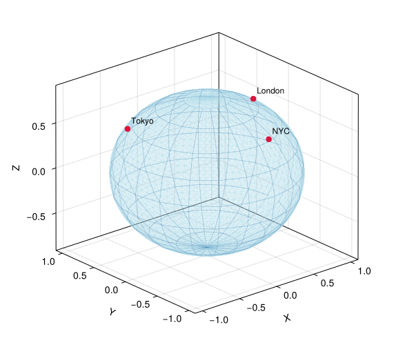

Figure 3.1: Three cities plotted in ECEF coordinates on a wireframe ellipsoid (flattening exaggerated 50x for visibility).

```julia
a = 1.0
f_exag = flattening(WGS84) * 50  # exaggerate flattening for visibility
b = a * (1 - f_exag)

theta = range(-pi/2, pi/2, 40)
phi = range(0, 2pi, 80)
X = [a * cos(t) * cos(p) for t in theta, p in phi]
Y = [a * cos(t) * sin(p) for t in theta, p in phi]
Z = [b * sin(t) for t in theta, p in phi]

# Cities in normalized ECEF
cities = [
    ("NYC", LLA(-74.006, 40.7128)),
    ("London", LLA(-0.1278, 51.5074)),
    ("Tokyo", LLA(139.6917, 35.6895)),
]
scale = semi_major_axis(WGS84)
city_ecefs = [(name, ECEF(lla, WGS84)) for (name, lla) in cities]

fig = Figure(size=(600, 500))
ax = Axis3(fig[1, 1], aspect=:data, xlabel="X", ylabel="Y", zlabel="Z")
surface!(ax, X, Y, Z, alpha=0.2, colormap=[:lightblue, :lightblue], shading=NoShading)
wireframe!(ax, X[1:4:end, 1:4:end], Y[1:4:end, 1:4:end], Z[1:4:end, 1:4:end],
    color=(:steelblue, 0.3), linewidth=0.5)

for (name, ecef) in city_ecefs
    px, py, pz = ecef.x / scale, ecef.y / scale, ecef.z / scale
    # Adjust for exaggerated flattening
    pz_exag = pz * (b / (a * (1 - flattening(WGS84))))
    scatter!(ax, [px], [py], [pz_exag], color=:crimson, markersize=12)
    text!(ax, px, py, pz_exag; text=name, fontsize=12, align=(:left, :bottom), offset=(5, 5))
end
fig
```